# GroupTrack<sup>OG</sup> — User Manual

See Account.

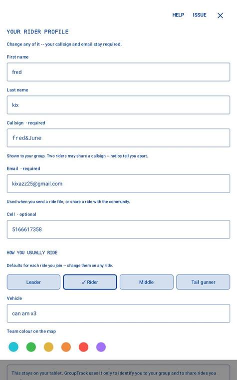

Your rider profile

What does it mean to me?

**Remove all trail data**

What is it?

Deletes every trail on this tablet — state trails and "Rider" trails — and their details, so trails can be imported again cleanly.

How do I use it?

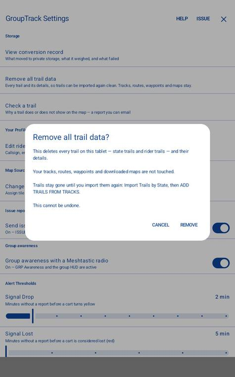

Remove all trail data

What does it mean to me?

A clean start when trails look wrong. Your tracks, routes, waypoints and downloaded maps are not touched.

**Admission Window**

What is it?

Under **Node Filter**. How recently a radio must have been heard from to be given a cart on the map. One hour by default; the slider runs to twelve.

A radio heard from inside the window gets a cart. One that has not been heard from does not — and its cart leaves the map once the window passes. Nothing is deleted: the radio stays in the list of radios GroupTrack<sup>OG</sup> knows, and its cart comes back by itself on the next position it sends. **Your own cart is never removed**, however long you have been out of touch.

How do I use it?

MENU › Settings › **Node Filter** › **Admission Window** — drag the slider. The figure beside it reads in hours. It takes effect on the next map refresh; nothing needs restarting.

Leave it at one hour for an ordinary ride. Widen it when the group is spread out over rough ground and reports are coming in slowly, or when you want to keep seeing where someone was after they dropped out of range.

What does it mean to me?

The map shows the riders who are actually out with you. Before Rel 2.8 every radio GroupTrack<sup>OG</sup> had ever met kept its cart, so riders who had gone home — or a radio switched off in a box at the house — still sat on the map, and the group view framed itself around them.

If a rider you can see is missing from your map, their radio is not being heard from: switched off, out of range, or with its serial connection turned off on the radio itself. Widening the window will not bring in a radio that is not transmitting.

With group awareness off, the map shows your cart and nothing else, and this setting does nothing.

**Ride statistics**

What is it?

How well the radios heard each other: for each cart, reports, minutes heard, the usual gap, the farthest heard, every loss, signal and channel use. Kept while group awareness is on, from when GroupTrack<sup>OG</sup> started.

How do I use it?

Settings › **Ride statistics** (the last line). **REFRESH** updates it; **RESET** starts again (for example between two tests). To send it to us after a ride: Rides › **Email last ride statistics to GroupTrack<sup>OG</sup>**.

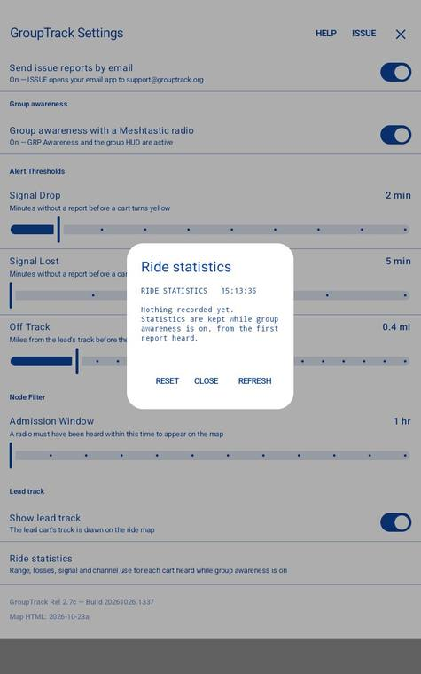

Ride statistics

What does it mean to me?

You can see how far your radios reach on your trails — and help us improve group tracking.

**View conversion record**

What is it?

The record of the one-time move of your GroupTrack<sup>OG</sup> files into GroupTrack<sup>OG</sup>'s own storage: what moved, its size, and anything that failed.

How do I use it?

Settings › **View conversion record**. Read it, or tap **SHARE** to send it to us if support asks. **CLOSE** to leave.

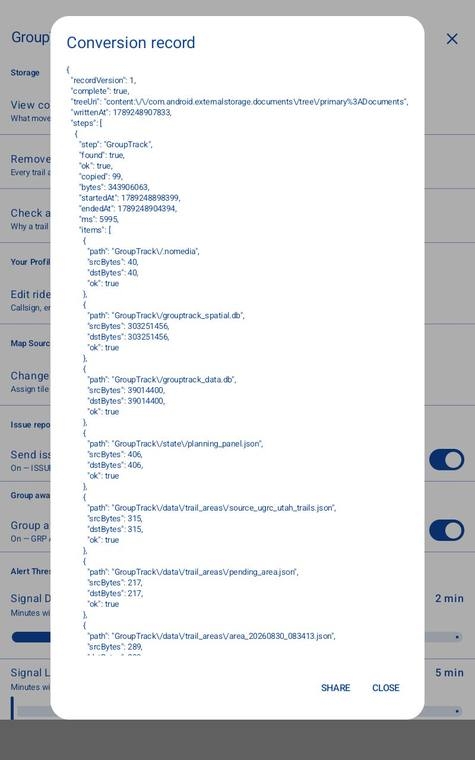

View conversion record

What does it mean to me?

If something seems missing after an update, this shows whether it was moved.

**B · Check in and recording tracks**

What is it?

The big button at the top centre runs your ride. What it shows depends on the mode:

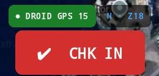

Group: CHK IN — check in first

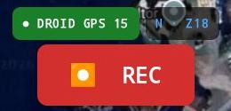

My device: REC — record straight away

How do I use it?

- **Group:** tap **✔ CHK IN** to check in to the ride; the button then reads **⏺ REC**.
- **My device** (or once checked in): tap **⏺ REC** to record. While recording it reads **⏸ PAUSE**; paused, it offers **RESUME** and **END**.

**Group adds one step: check in.** After that the button works exactly as it does in My device.

What does it mean to me?

One button, always in the same place, from the trailhead to the end of the ride.

**Check in**

What is it?

Checking in puts you on a ride: which ride, the callsign you ride under, and your role — and it sets your radio up for the ride's network, so you hear the group and the group sees you.

How do I use it?

At the trailhead, radio on and connected, tap **✔ CHK IN**:

1. **Which ride?** Tap the ride (All, or one organizer's rides). A ride dated today is already chosen. Not on a planned ride? Tap **No scheduled ride** — a normal recording: no survey and no sharing; you name the track at the end.
2. **Callsign for this ride** — yours to start with; change it for this ride only (a shared cart, a guest driver).
3. **Role** — Leader, Rider, Middle or Tail gunner. If someone already holds the role, GroupTrack<sup>OG</sup> says who; choose another.
4. Tap **CHECK IN**. If your radio is not set for the ride yet, it is set up first (about a minute, with its progress on screen).

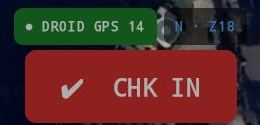

Before: ✔ CHK IN

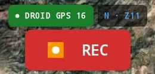

Checked in: ⏺ REC — tap it when the group rolls out

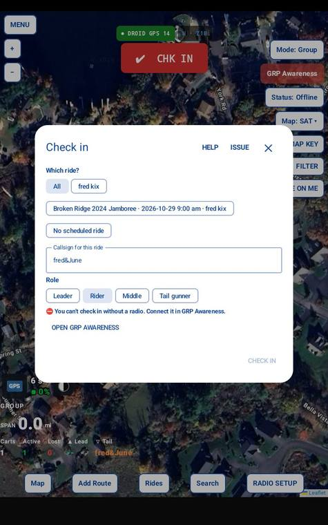

Check-in group aware

**Check in.** Choose the ride (or **No scheduled ride**), check your callsign, tap your role, then **CHECK IN**.

No radio connected? The red line says so: tap **OPEN GRP AWARENESS** and connect it first.

Checked in, the button reads **⏺ REC** (above) — checking in does not start recording — and the map shows the ride's route and waypoints.

What does it mean to me?

One step puts you on the ride and tells the group you are there — with your role on everyone's map.

**More: Checking in, step by step**

**Everybody checks in first thing at the trailhead.** Radio on, GroupTrack<sup>OG</sup> started, check in. Checking in is what puts your radio on the ride's network — until then it cannot hear the group. The Leader, Middle and Tail gunner check in among the first, so the whole group learns their roles.

- **Which ride?** Every ride on your tablet, newest first, opened at today. If exactly one is dated today, it is already chosen. Pick **No scheduled ride** for a recording that is not part of a ride — your radio goes back to the GroupTrack<sup>OG</sup> default network (tick **Keep my radio as it is** to leave it alone).
- **Callsign for this ride** — yours to start with; change it for this ride only (a shared cart, a guest driver).
- **Role** — Leader, Rider, Middle or Tail gunner. There is one of each of the first three: if another rider already holds the role you choose, GroupTrack<sup>OG</sup> says who, and you choose another.
- **Your radio** — GroupTrack<sup>OG</sup> compares it with the ride: "Radio ready for this ride", or it is set up when you check in (about a minute, with its progress on screen). If it cannot finish, the check-in reopens with your choices kept.

**The readout after check-in**

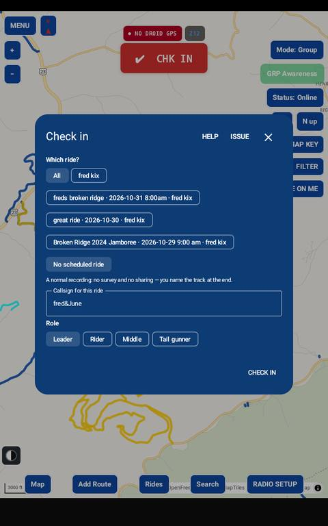

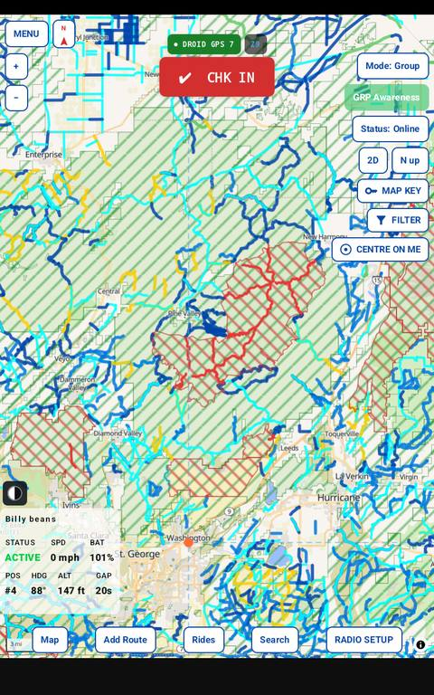

Toggled to dark maps light presentation

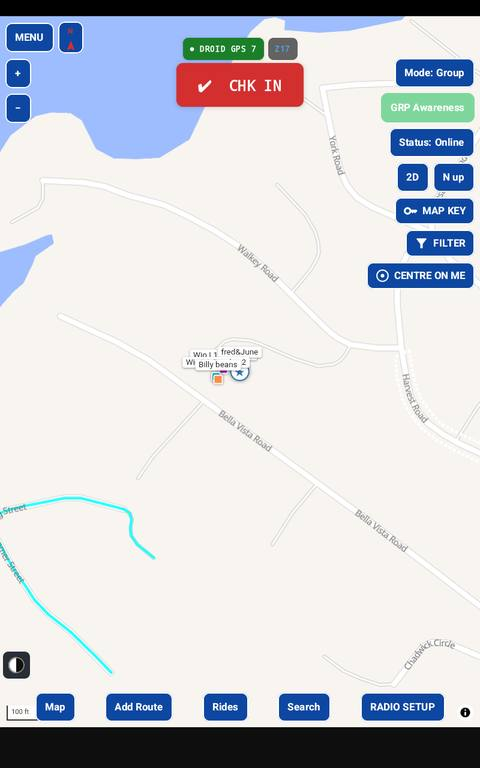

Light maps. dark navigation through black and white icons

What is it?

The readout has a dark backing with white text, so it reads over any map. The black-and-white button switches it, with the rest of GroupTrack<sup>OG</sup>, to dark text on a light backing.

How do I use it?

- **View: Group** — the readout shows the group: span (lead to tail), carts, active, lost, the lead and the tail.
- **View: My Cart** — your own cart: heading, battery, altitude, speed, and the distance to the lead and the tail.
- **View: No HUD** — the readout and the GPS line are hidden (the black-and-white button stays), so the map has the whole screen. The map keeps every cart in view, as on View: Group. A **CONTACT LOST** warning still shows: a lost cart is never hidden. Tap View again to bring the readout back (View: Group).
- **Tap a cart on the map** to see that cart's readout; closing it returns to View: Group.

[figure not shown]

After check-in routes becomes my cart or group cart check-in becomes record

**After check-in** the bottom bar's Add Route becomes **View**: tap it to go from the whole group to your cart to no readout at all (View: No HUD), and back to the group.

What does it mean to me?

At a glance you know where the group is and how strung out it is — and when you want all of the map, one more tap clears the readout away without losing a lost-cart warning.

**Recording**

What is it?

Recording writes your track — where you went — as you ride.

How do I use it?

- Tap **⏺ REC** to start. The button becomes **⏸ PAUSE**, CENTRE ON ME becomes **FOLLOWING ME**, and the distance recorded shows in red at the bottom right.
- Stopping for a break? Tap **⏸ PAUSE**, then **RESUME** to carry on the same track.
- Finished? From PAUSE, tap **END** (see Ending the ride).

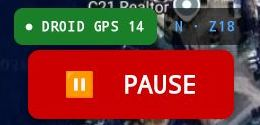

Recording: ⏸ PAUSE

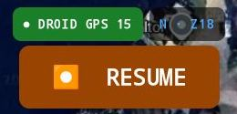

Paused: RESUME

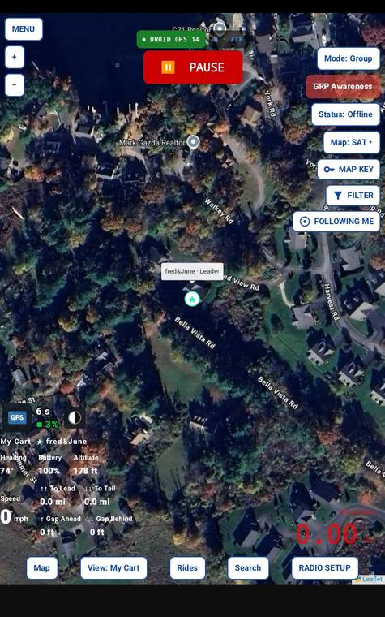

Record running

**Recording.** The button reads **⏸ PAUSE**, CENTRE ON ME reads **FOLLOWING ME**, and the distance recorded shows in red at the bottom right.

Stopping for a break? Tap **⏸ PAUSE**; it becomes **RESUME** (above) — tap it to carry on the same track.

What does it mean to me?

Every ride is recorded as a track you can follow again, turn into a route, or share.

**Ending the ride**

What is it?

Ending the ride saves your track — named after the ride — and, on a public ride, asks how it was.

How do I use it?

Tap **⏸ PAUSE**, then **END**. **Save your ride** opens:

- **A scheduled ride:** the track name is the ride's name. Rate it (stars), choose the difficulty (Easy, Moderate, Hard), would you recommend it (Yes / No), notes if you like, and **Share this ride's track with the community?** — Yes, share it / No, keep it. SAVE is ready once those are chosen (the line above SAVE says what is missing).
- **No scheduled ride:** just name the track and SAVE.

**DELETE** throws the recording away (it asks first). After saving, the button reads ✔ CHK IN again.

[figure not shown]

Pause end

**Finished?** Tap **⏸ PAUSE**; under it, tap **END**.

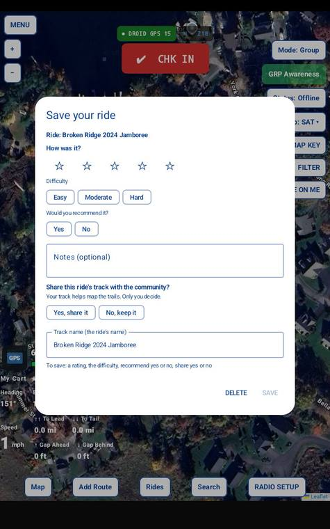

Save for scheduled ride

**Save your ride.** On a scheduled ride: rate it, choose the difficulty, say whether you recommend it, and whether to share the track with the community — then **SAVE** (the line above SAVE says what is still missing). With **No scheduled ride**, just name the track and SAVE.

What does it mean to me?

Your ride is filed under its name; your rating helps the next group decide, and only you decide whether your track is shared.

**More: What the end-of-ride form asks**

- **A ride:** the track is named after the ride — every rider's recording of it carries the same name.
- **A public ride:** rate it (1–5 stars), its difficulty, whether you would recommend it, notes if you like, and **Share this ride's track with the community?** — Yes or No, every time; there is no default. SAVE is available once they are done.
- **A private ride:** no survey and no sharing — your track stays on your tablet.
- **No scheduled ride:** you name the track; no survey, no sharing.

Your survey belongs to the ride — one per rider; saving again replaces it. The track is yours: only you decide whether it is shared. DELETE asks before throwing a recording away.

**C · Mode — My device or Group**

**MYDEVICE-2026-11-19:** the mode is now called **My device** (it read “Android only” up to 2.8a) and the GPS lamp reads **MY DEVICE GPS n** (it read “DROID GPS n”). The screenshots in this section were captured before that change and still show the OLD wording — **recapture owed**. The text here is what the app says now.

What is it?

Mode switches GroupTrack<sup>OG</sup> between its two ways of riding. **My device**: you ride on your own with no radio, and the tablet's GPS places your cart. **Group**: you ride with others who carry mesh radios, and every cart in the group is on your map. Mode does not change carts or riders — it changes what GroupTrack<sup>OG</sup> does.

How do I use it?

1. Tap **Mode** on the right side. It switches to the other mode, and the button says which you are in.
2. **My device**: the ride button is **REC**; GRP Awareness is grey. Maps, trails, routes, rides and search all work.
3. **Group**: the group buttons appear — **GRP Awareness**, **CHK IN**, **View: My Cart / Group** and **RADIO SETUP**.

Mode cannot be switched while you are recording: end the ride first. In My device, the GPS lamp at the top (**MY DEVICE GPS n**) places your cart, so it should be green before you ride.

[figure not shown]

My device: one rider, no radio — REC, GRP Awareness grey

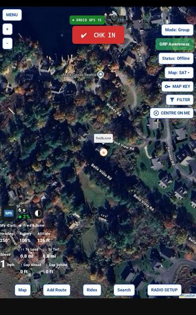

What does it mean to me?

The screen shows only what your kind of ride needs: nothing about radios when you ride alone, the whole group when you ride together.

**D · GRP Awareness — connect your radio**

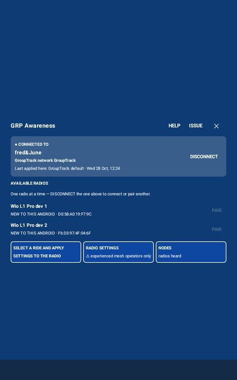

GRP Awareness: the buttons, outlined

What is it?

GRP Awareness is your link to your mesh radio. The button's colour tells you its state at a glance — **green**: your radio is connected and talking to GroupTrack<sup>OG</sup>; **red**: it is not — and a tap opens the panel where you connect, pair or forget a radio.

How do I use it?

Tap **GRP Awareness** on the right side (Group mode). The panel is shown below, with what to tap beside it. The lines under it lead on to each job in its own section: Bluetooth, FORGET, NODES, RADIO SETTINGS, and selecting a ride and applying its settings.

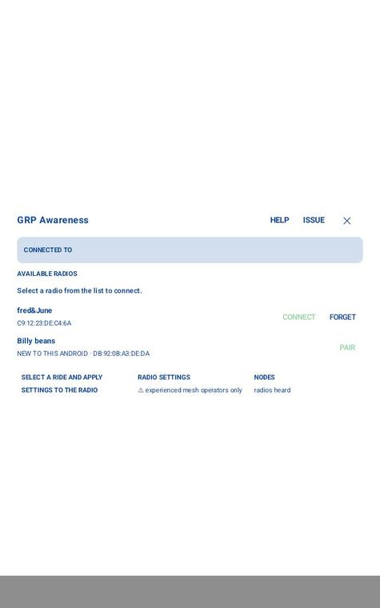

Radio settings connect, forget, pair. select a ride, radio settings nodes

**The panel.**

- **To connect your radio:** tap **CONNECT** beside it under AVAILABLE RADIOS. It moves to CONNECTED TO; the button turns green when it talks.
- **A radio new to this tablet** (marked NEW TO THIS ANDROID): tap **PAIR** and enter the radio's PIN when Android asks.
- **To change radios:** tap **DISCONNECT** beside the one connected — one radio at a time.
- **To remove a radio:** **FORGET** (its own section below).
- **No radios listed?** If Android has not let GroupTrack<sup>OG</sup> find nearby devices, the panel says so: tap **ALLOW**.

What does it mean to me?

You know before you roll out that your radio is talking — and so that the group can see you and you can see them.

**More: Radio range and group size**

**A quiet channel.** GroupTrack<sup>OG</sup>'s radios use the MEDIUM_FAST setting and report every 30 seconds standing and, moving, every 30 metres — at most every 6 seconds. Channel use stays low (about 3–5% with two radios), so many riders fit on one ride.

**Range.** On a T1000-E, plan on about ¾ mile between riders in open country; terrain and trees shorten it, a clear line of sight lengthens it. Radios with a bigger antenna or more power reach further. (Estimates, being measured on real trails — Ride statistics shows yours.)

**Radios relay for each other.** A rider out of direct reach is still heard through the riders between you, so a strung-out group stays connected as long as no gap between riders is longer than a radio's reach.

**Strong radios make a backbone.** A radio with a good antenna — 1 watt, mounted high — reaches much further and hears weak radios better. Put strong radios at the lead, the tail and the middle of a long group. The leader's radio matters most: it carries the leader's track to everyone behind.

**Every radio on a ride must use the same setting.** GroupTrack<sup>OG</sup> sets it when the ride is applied; radios set differently cannot hear each other at all.

**Bluetooth off**

What is it?

Your radio talks to the tablet over Bluetooth. GRP Awareness tells you when Bluetooth is off, and turns it on or off from the panel.

How do I use it?

- **To turn it on:** the panel says *Bluetooth is off*. Tap **BLUETOOTH**; Android asks *GroupTrack<sup>OG</sup> wants to turn on Bluetooth* — tap **Allow**. Your radios appear.
- **To turn it off** (no radio connected): under the radio list, tap **TURN BLUETOOTH OFF**. Android's Bluetooth page opens: use the switch at the top, then come back. A radio connected? DISCONNECT it first.

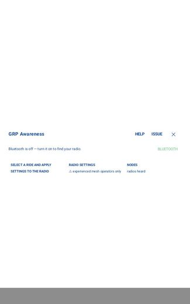

Bluetooth off: GRP Awareness says so — tap BLUETOOTH

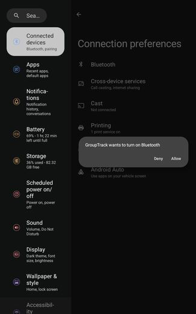

Android asks: GroupTrack<sup>OG</sup> wants to turn on Bluetooth — tap Allow

What does it mean to me?

Bluetooth on or off without leaving GroupTrack<sup>OG</sup> to hunt through Android's settings.

**FORGET**

What is it?

FORGET removes a radio from GroupTrack<sup>OG</sup> and from this tablet's Bluetooth pairings.

How do I use it?

1. In the GRP Awareness panel, tap **FORGET** beside the radio.
2. Confirm: **FORGET** (or CANCEL).
3. If Android needs you to do it, GroupTrack<sup>OG</sup> says so and opens Android's Bluetooth page: tap the radio, then **Forget**, and come back.

To use the radio again, **PAIR** it again.

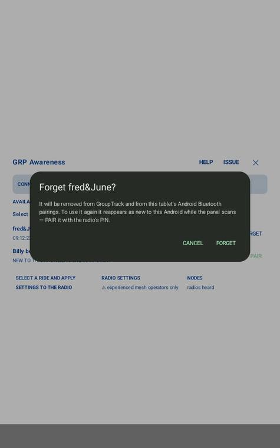

Forget

What does it mean to me?

A radio you sold, lent or replaced no longer shows up — and cannot connect by mistake.

**NODES**

What is it?

NODES lists every radio your radio has heard, with its details.

How do I use it?

In the GRP Awareness panel, tap **NODES**. It is for looking only — for experienced Meshtastic users researching a radio problem.

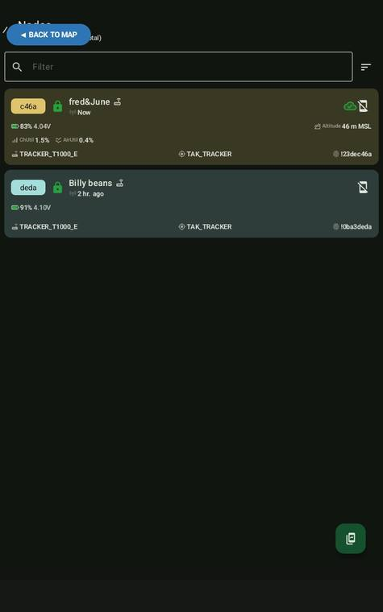

Node info

What does it mean to me?

Nothing to do here on an ordinary ride; when a radio misbehaves, it shows what your radio has heard.

**RADIO SETTINGS**

What is it?

The radio's own full settings, in the Meshtastic screens.

How do I use it?

In the GRP Awareness panel, tap **RADIO SETTINGS**. **For experienced mesh operators only:** GroupTrack<sup>OG</sup> sets everything a ride needs itself (N · RADIO SETUP), and a change made here can stop your radio from hearing the group.

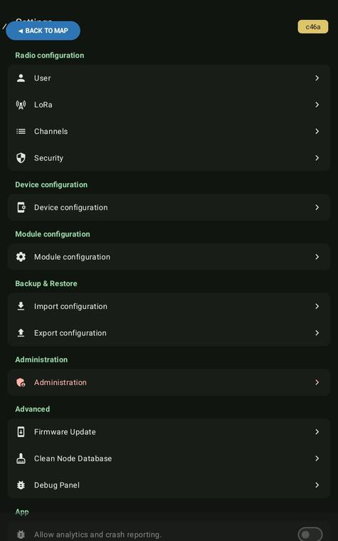

Mesh radio config

What does it mean to me?

Nothing to do here for an ordinary ride — it is there for those who know the radios.

**Select a ride and apply settings to the radio**

What is it?

Puts a ride's radio settings on your radio — the same job as RADIO SETUP › Configure radio (N).

How do I use it?

1. In the GRP Awareness panel, tap **SELECT A RIDE AND APPLY SETTINGS TO THE RADIO**.
2. Tap the ride (or the default settings), then apply. The radio is set up — about a minute, with its progress on screen.

Full steps: N · RADIO SETUP › Configure radio for rides.

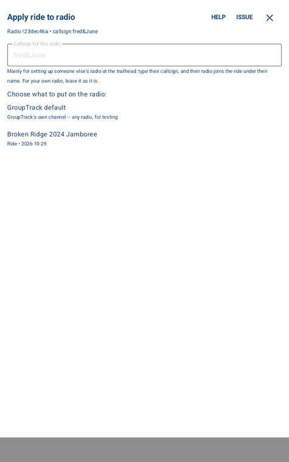

Choose a ride, or the default settings, to apply to the radio

What does it mean to me?

Your radio is on the ride's network before you get to the trailhead.

**E · Status — Online or Offline**

What is it?

Status says whether GroupTrack<sup>OG</sup> is using the internet, and lets you switch it off on purpose. **Online**: the map shows everywhere — your stored maps first, the internet for the rest — so you can plan anywhere, and searches use the internet. **Offline**: GroupTrack<sup>OG</sup> uses only what is on the tablet — your downloaded maps and data.

How do I use it?

- **To try your offline maps before you leave:** tap **Status: Online**; it becomes **Status: Offline**. Look over the ride area: what you see is what you will have with no signal.
- **To go back online:** tap **Status: Offline**.

Offline, if you zoom closer than your stored maps go in that place, the map steps back to the last zoom it has and says **No maps downloaded below this zoom here**.

With no internet, GroupTrack<sup>OG</sup> is offline anyway and the button says so.

What does it mean to me?

No surprises when the signal goes: you have seen your maps work without it before you ride.

**The map from the internet while you are online (new in 2.7e)**

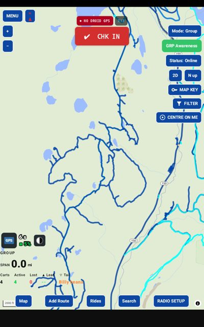

Status: Online — the map comes from the internet where nothing is downloaded

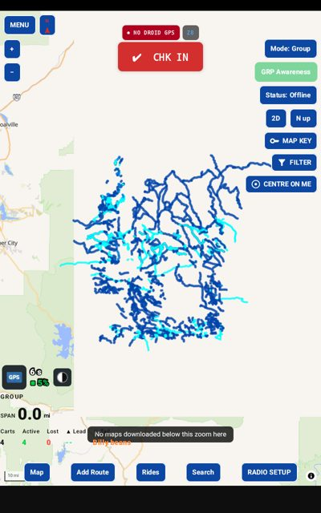

Status: Offline — the same area shows only what is stored on the tablet

What is it?

Online, the map shows everywhere — your stored maps first, the internet for the rest — so you can plan anywhere. Internet map is drawn, never saved; downloads are what put maps on the tablet.

How do I use it?

- Online: just use the map.
- To check what you have stored: tap **Status: Online** → **Status: Offline**.

What does it mean to me?

You can plan a ride anywhere, and still check before you leave exactly what will work with no signal.

**No maps downloaded below this zoom here (new in 2.7e)**

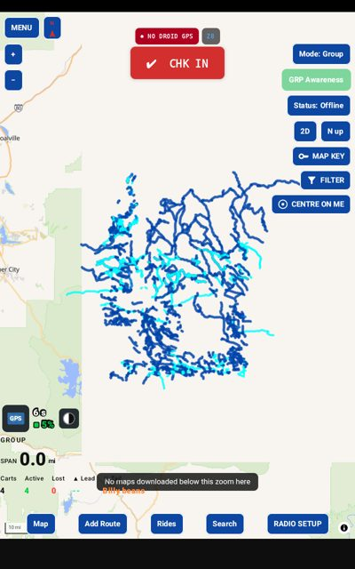

Offline past your stored maps — the note No maps downloaded below this zoom here

What is it?

Offline, if you zoom closer than your stored maps go in that place, the map steps back to the last zoom it has and tells you.

How do I use it?

- Nothing to do — it is a note. Download that area (Map › Download maps by area) for closer zooms there.

What does it mean to me?

No blank map and no guessing — you see what you have.

**F · Map view — 2D / 3D and N up / My dir**

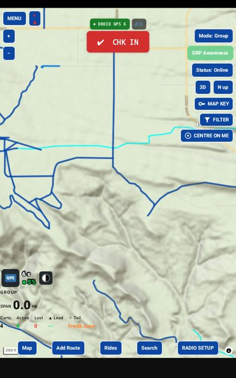

Map standard 2D

What is it?

GroupTrack<sup>OG</sup> has **one map**: roads, trails, water, places and their names, drawn on your tablet, with the shape of the ground underneath. It replaces the satellite and topo maps (SAT, TOPO, TOPO+). Two buttons on the right side, where the Map type button was, change how you look at it.

How do I use it?

- **2D / 3D** — tap **3D**: the ground rises into hills and canyons, the slopes are shaded and the map tilts. Tap **2D** for the flat map. It works with no signal, from the ground shape downloaded with your maps; where none is downloaded the ground shows flat.
- **N up / My dir** — tap **My dir**: the map turns so the way you are travelling points up, and follows your turns. Below walking speed the direction is not reliable, so when you stop the map holds the last direction instead of spinning. Tap **N up** to put north back at the top.
- **The compass** — beside MENU. Its red needle points north as the map turns; tap it for north up (My dir goes off). **+** and **−** under MENU zoom; the zoom shows as **Z** and a number.
- **Fingers on the map** — drag to move, pinch to zoom, two fingers turned to rotate, two fingers pushed up or down to tilt. 3D draws at every zoom you can reach.

The black-and-white button switches every panel in the app between light and dark.

What does it mean to me?

You see the climb before you get to it, and the map faces the way you ride.

**3D — the shape of the ground (new in 2.7e)**

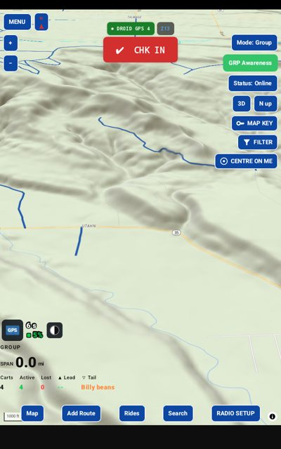

Map 3D

What is it?

The ground raised into hills and canyons, with the slopes shaded, from the elevation downloaded with your maps. Where no elevation is downloaded the ground shows flat.

How do I use it?

1. Tap **3D** on the right side. The ground rises and the map tilts.
2. Tap **2D** for the flat map.

What does it mean to me?

You can see the climb before you get to it.

**Tilt the map (new in 2.7e)**

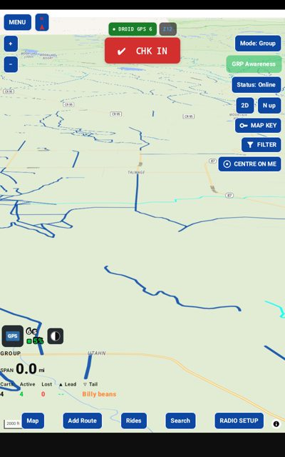

Map 2D tilted

What is it?

Tilting leans the map back so you look out ahead across the ground, the way you see it from the seat. It works in 2D and in 3D.

How do I use it?

1. Put **two fingers side by side** on the map — as you would to zoom.
2. **Slide them up together** to tilt; slide them down to flatten the map again.

What does it mean to me?

The trail ahead looks the way it does through the windshield.

**N up / My dir — which way is up (new in 2.7e)**

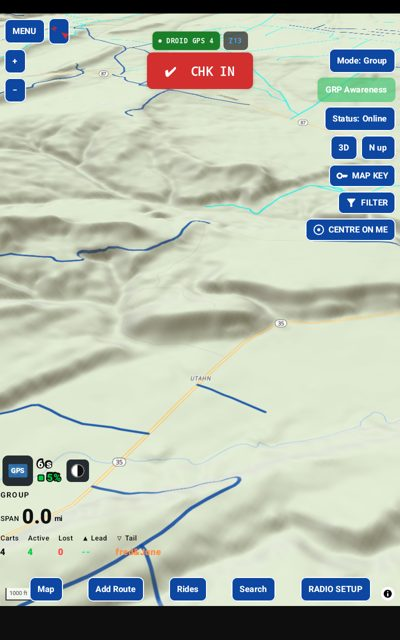

Map rotated

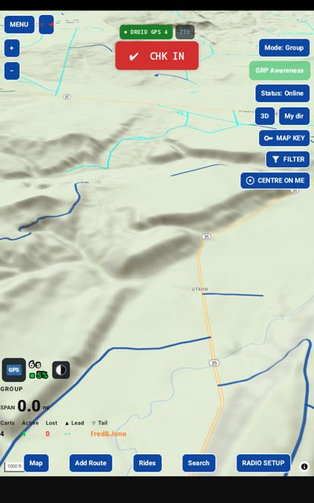

Map rotated by "My dir" up

What is it?

The map can keep north at the top (**N up**) or turn so the way you are going is up (**My dir**).

How do I use it?

1. Tap the button to switch between **N up** and **My dir**.
2. In My dir the map follows your turns; when you stop it holds the last direction instead of spinning.

What does it mean to me?

The map faces the way you ride.

**The compass (new in 2.7e)**

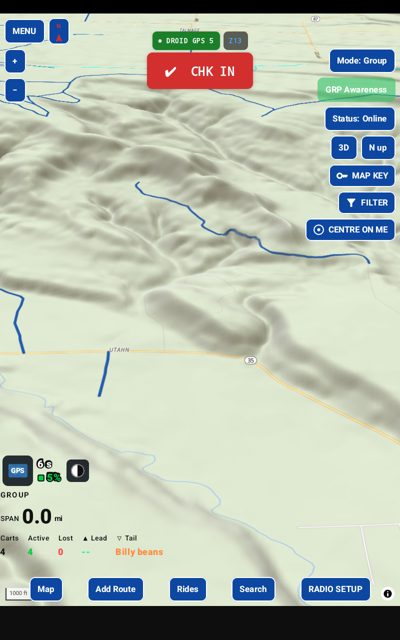

N up: compass orientation, always north on top

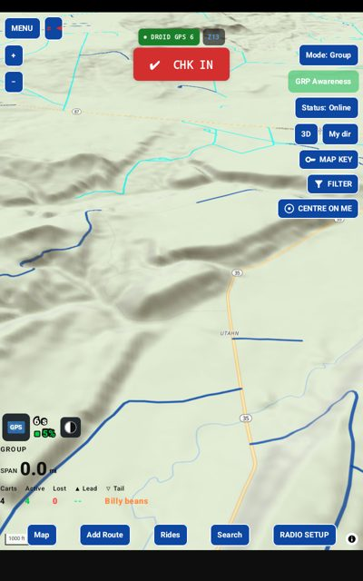

My dir: the compass N rotates

What is it?

A compass beside MENU. Its red needle points north however the map is turned. The map's own zoom buttons are gone — **+** and **−** under MENU zoom, and the zoom shows as **Z** and a number.

How do I use it?

- Tap the compass to put north back at the top (My dir goes off).

What does it mean to me?

You always know which way north is, at a glance.

**G · MAP KEY — what the lines and symbols mean**

What is it?

MAP KEY explains everything drawn on the map — the trails by category, your tracks and routes, the lines drawn while you ride, and the group's carts — and lets you change how each one looks.

How do I use it?

Tap **MAP KEY** on the right side. It stays open beside the map and scrolls; each part is shown below with what to do beside it.

[figure not shown]

Maps key decode artifacts

**Reading the map:** find the line's colour and pattern here to know what it is — the trails, motorized first.

- **To change how a kind of line looks:** tap **STYLE ›** on its row. Style a row opens (below): choose the colour, pattern and thickness; the map redraws as you choose.
- **To keep the key in view while you look:** drag it by **☰ MOVE**; tap **HIDE** to fold it to its title and again to open it.
- **To close it:** ✕.

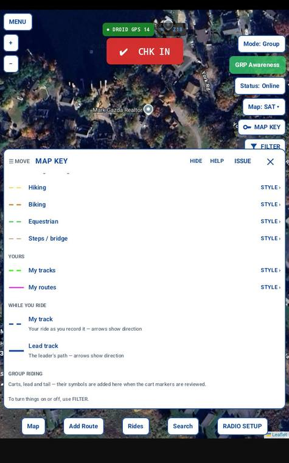

Decoder screen 2

**Scroll down for your own lines and the group.**

- **YOURS** — your tracks and routes. Tap **STYLE ›** to make them stand out from the trails.
- **WHILE YOU RIDE** — **My track** (your ride as you record it) and the **Lead track** (the leader's path). The arrows on them show the direction travelled.
- **GROUP RIDING** — the carts, lead and tail.

**To turn any of these on or off,** use FILTER (H) — the key only explains and styles them.

What does it mean to me?

Every line and symbol on your map is explained, and you can make the ones that matter to you stand out.

**Style a row**

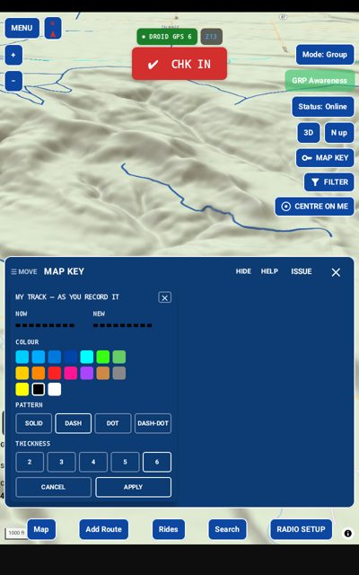

New style colour palette

What is it?

Changes how one kind of line or symbol is drawn — its colour, pattern and thickness.

How do I use it?

1. In MAP KEY, tap **STYLE ›** on the row.
2. Tap a colour, a pattern and a thickness. The map redraws as you choose.
3. Close with ✕; your choice stays.

What does it mean to me?

The trails you ride, or your own tracks, stand out the way you like them.

**LAND — stripes and red trails (new in 2.7e)**

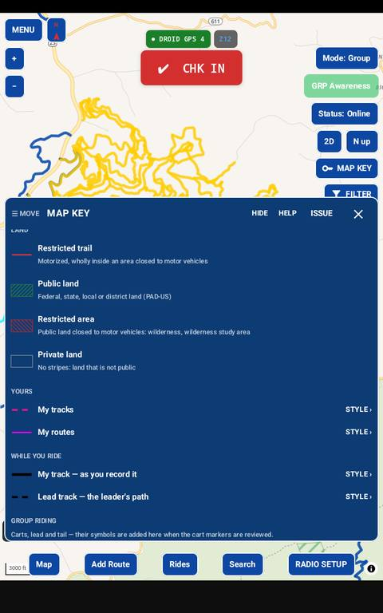

MAP KEY: the LAND section

What is it?

The LAND section of MAP KEY explains the land drawing: **Restricted trail** (red line), **Public land** (green stripes), **Restricted area** (red stripes, the other direction), **Private land** (no stripes — the plain map).

**H · FILTER — what shows on the map**

What is it?

FILTER chooses what is drawn on the map: each type of thing (trails, tracks, routes, waypoints), each kind of trail, public and private land, and where your offline maps reach. It stays open beside the map while you change it, so you see the result as you tick.

How do I use it?

Open **FILTER** on the right side. The panel scrolls; each part is shown below with how to use it.

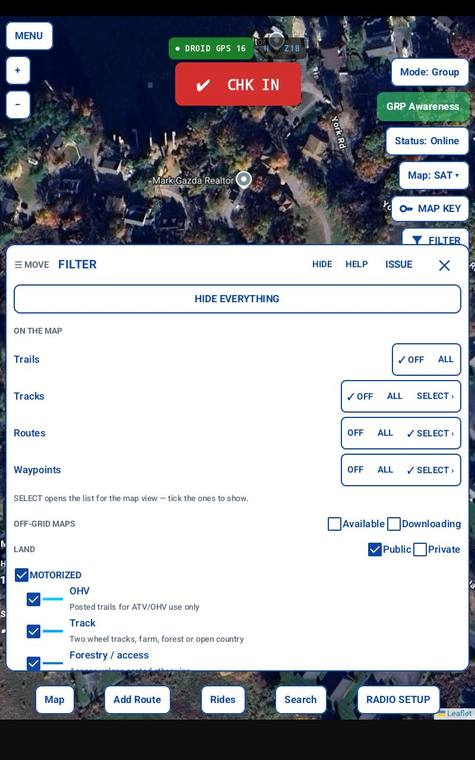

Map filter screen 1 scrolls

**The top of FILTER.**

- **To clear the map:** tap **HIDE EVERYTHING**. The button becomes **SHOW AGAIN — restore what was on**: tap it to bring back exactly what was showing.
- **To show or hide a whole type:** on its line under ON THE MAP, tap **ALL** to show every one or **OFF** to hide them. The tick shows the current setting.
- **To show only some tracks, routes or waypoints:** tap **SELECT ›** on that line. The list of that type in the map view opens: tick the ones you want (SELECT ALL and DESELECT ALL tick or clear the lot; FIT fits the map to the ticked ones), then tap **✕** — the ticks are applied. Which trails show is chosen in the list further down, not with SELECT.
- **To see where your offline maps reach:** tick **Available** (areas downloaded) and / or **Downloading** (areas still coming). Untick to remove the outlines.
- **To see only trails on private land:** untick **Public**. **Only public trails:** untick **Private**. One of the two always stays ticked.

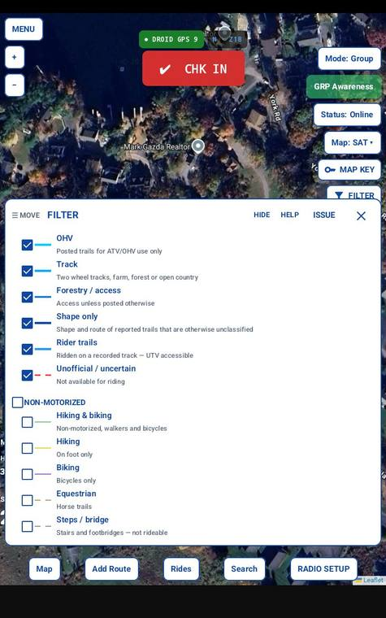

Filter screen 2

**Scroll down for the trail categories.**

- **To hide one kind of trail** (for example Unofficial / uncertain): untick it. Tick it again to show it.
- **To show or hide a whole group:** tap its heading — **MOTORIZED** or **NON-MOTORIZED**. If every kind in the group is on, the tap turns them all off; otherwise it turns them all on.
- **To check what a category means:** read the line under its name — for example "Rider" trails (made from your tracks — Create trails from tracks) are ridden on a recorded track and UTV accessible; Steps / bridge are not rideable.

The map changes as you tick. The colours of each kind are changed in MAP KEY (G).

What does it mean to me?

A map that shows only what matters for the ride in front of you. You can check which trails cross private land before you go, hide what you cannot ride, and see where your offline maps run out before you lose signal.

**Up to 1,000 trails in view (new in 2.7e)**

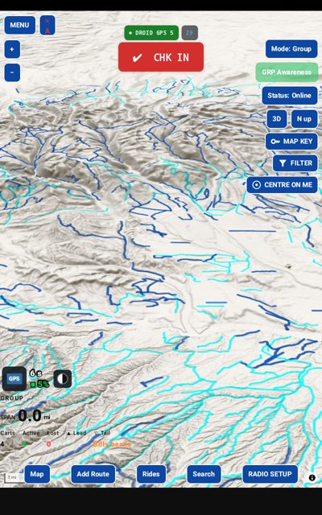

Low zoom: 1,000 trails max, always the longest. Zoom in reveals more detail.

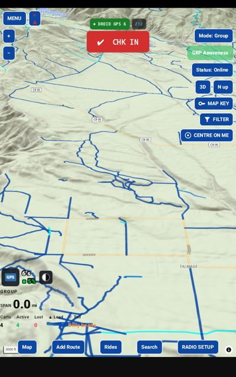

More detailed maps as zoom increases

What is it?

The map shows up to 1,000 trails in view at a time — named trails first, then the largest — so it stays quick over a wide area.

How do I use it?

- Zoom in to see every trail in a smaller area.

What does it mean to me?

The map stays fast however many trails you have imported.

**Land — public, private and restricted (new in 2.7e)**

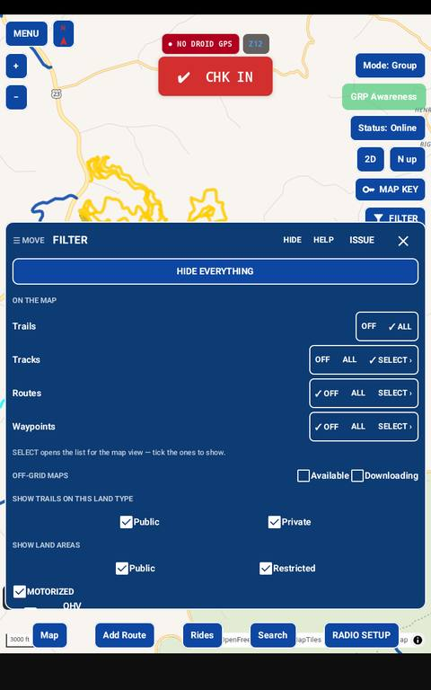

FILTER, first page

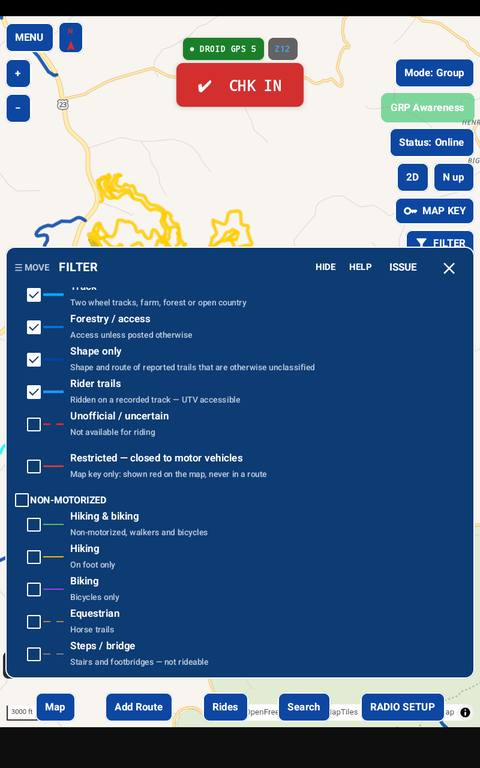

What is it?

Land ownership shows in two places in FILTER. **Show trails on this land type** — Public, Private — chooses which trails are drawn. **Show land areas** — Public, Restricted — turns the striped land overlays on and off. In the **MOTORIZED** section, the row **Restricted — closed to motor vehicles** shows, in red, the parts of motorized trails inside wilderness and wilderness study areas. The land comes from the U.S. government's public-lands database (USGS PAD-US).

How do I use it?

- **Public** — trails on public land (federal, state, county and district land). On by default.
- **Private** — trails on private land. Off by default. Private riding parks (for example Hillbilly Hills near Pikeville, Kentucky) are private land: tick Private to see their trails; permits and fees are your responsibility.
- **Restricted — closed to motor vehicles** (in MOTORIZED) — the red parts of trails inside areas closed to motor vehicles. It is a map key only: route building never uses a restricted piece, whatever is ticked; a trail that crosses one is used only on its open parts.
- Searching for routes uses the Public and Private ticks. With both on, every trail you may ride is searched, and the map shows which parts cross private land — permission and fees are your responsibility.

What should I see?

Ticking a box redraws the map at once. Land areas show from map zoom 9.

**I · CENTRE ON ME**

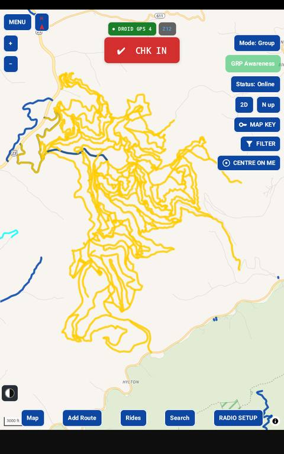

CENTRE ON ME — always CENTRE ON ME: one jump to you

What is it?

**CENTRE ON ME** brings the map back to you: one jump to where you are. It does not keep following you — the button always says CENTRE ON ME.

How do I use it?

- **To find yourself:** tap CENTRE ON ME. The map moves to you, once.
- **While you record, the map follows by itself:** on **View: My Cart** it keeps your cart in the middle; on **View: Group** and **View: No HUD** it keeps the whole group in view.
- **To look around:** drag the map. While recording, following starts again 15 seconds after your last touch.
- **A search stops following,** so the map stays where the search put it.

What does it mean to me?

On the trail you always start on yourself or your group: look around, and the map comes back.

**J · Map — downloads, imports and map recovery**

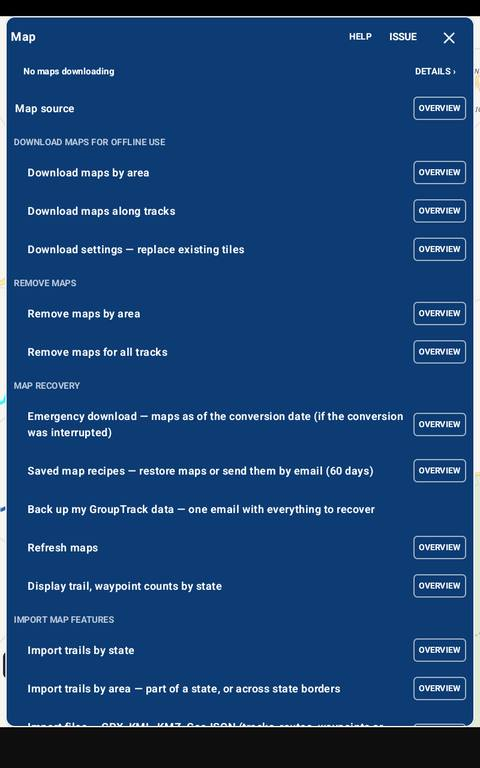

The Map menu, page 1 — tap a name to run it, OVERVIEW to read first

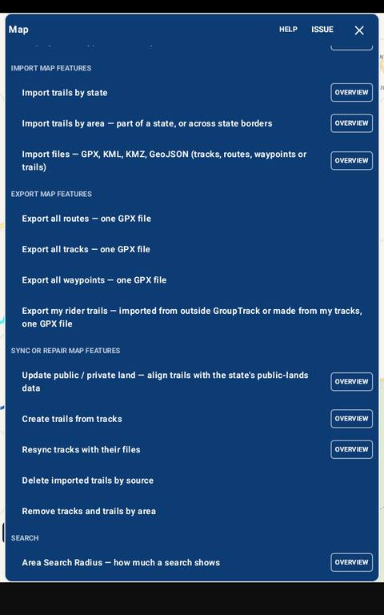

The Map menu, page 2

What is it?

**Map**, first on the bottom bar, holds every map job: what is downloading, the map source, downloading and removing maps, map recovery, and every import.

How do I use it?

Tap **Map**. The framed line at the top says how the menu works: **tap a function's name to run it; tap OVERVIEW first** to read what it does and how to use it — OVERVIEW opens that function's section of this manual and runs nothing. The menu scrolls; its groups, top to bottom:

- **The first line** — what is downloading; DETAILS › opens the queue.
- **Map source** — where the map comes from.
- **DOWNLOAD MAPS FOR OFFLINE USE** — by area, along tracks; Download settings.
- **REMOVE MAPS** — by area; for all tracks.
- **MAP RECOVERY** — Emergency download, Saved map recipes (today's recipe brings your maps up to date), Back up my GroupTrack<sup>OG</sup> data, Display trail, waypoint counts by state.
- **IMPORT MAP FEATURES** — Import trails by state, Import trails by area, Import files (GPX, KML, KMZ, GeoJSON).
- **EXPORT MAP FEATURES** — all routes, all tracks, all waypoints, my rider trails.
- **SYNC OR REPAIR MAP FEATURES** — Update public / private land, Create trails from tracks, Resync tracks, Delete imported trails by source, Remove tracks and trails by area.
- **SEARCH** — Area Search Radius.

What does it mean to me?

Get the maps and trails you need before you lose signal, all from the map you ride with.

**Create trails from tracks**

Overview

**What it does.** Turns the parts of your tracks that run where no trail is mapped into **"Rider"** trails — ground you have actually ridden becomes trail you can see and route on. **"Rider"** is a trail type you can identify in FILTER. Each track keeps its own name; the "Rider" trails it creates are **unnamed**, and are made **only for the sections of your track where no known trail exists** — extending your trail network. GroupTrack<sup>OG</sup> does this **automatically** every time a track is recorded or imported, so your unnamed "Rider" trails are always kept current; this function is the backstop for the cases below.

**How you use it.** Map › SYNC OR REPAIR MAP FEATURES › **Create trails from tracks** › **START**. It adds the new pieces and removes the ones your tracks no longer make; running it again does no harm.

**What it means to you.** The places you have ridden that no map shows become trails — on your map and in your routes — joined to the trail network at both ends.

**When to use it:**

- **Once**, for tracks recorded or imported **before 2.7c (26 October 2026)** — GroupTrack<sup>OG</sup> did not yet make trails when a track was saved. Tracks *imported after* that date need nothing: *the import itself creates their trails.*
- **Every time you import trails** (by state, by area, or from a file) — the new trails can give your tracks places to connect to the larger network, and a trail import does not redo your trails from tracks.
- **When trails are not connected** and you know your tracks provide that missing connection.

Step by step

**If you recorded or imported tracks before 2.7c (26 October 2026), or you have just imported trails, run this task:** Map › **Create trails from tracks** › **START**. Running it again does no harm.

[figure not shown]

Add trails if no trails exist in recorded area

**Download maps along tracks**

Overview

**What it does.** Saves the maps along every track or route you choose, in one tap — about 8 km (5 miles) on each side of the line.

**How you use it.** Pick the tracks or routes, tap DOWNLOAD. No boxes to draw or position.

**What it means to you.** Exploring off the line or taking a wrong turn does not leave you without a map, just when you need it most.

**When to use it.** Before riding a route you built, or a track someone sent you.

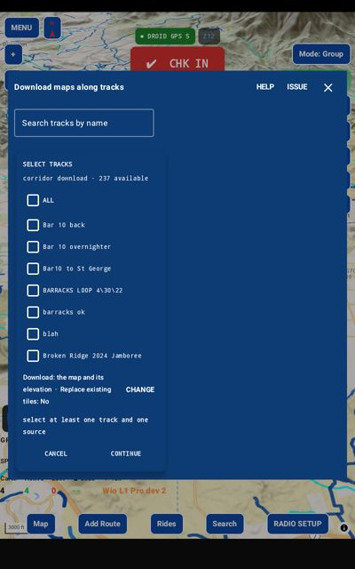

Track to select for map downloads

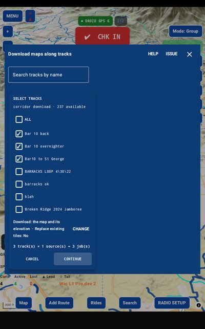

Step by step

1. Map › **Download maps along tracks**.
2. Tick the tracks (**ALL** for every one; **Search tracks by name** to find one). The line above shows how many jobs it makes.
3. **CONTINUE** — the maps go into the download queue. Each job carries the track's name (DL VEC 1/2 · Bar 10); a box shared by several tracks names them.

The area is about 8 km of map on every side of the track, in squares joined into tidy boxes; where tracks share ground it is downloaded once.

**Download maps by area**

Overview

**What it does.** Saves the map data inside a box you draw, so it works with no signal.

**How you use it.** Before you ride an area, draw the box round it, check the estimate and tap DOWNLOAD. The download queue shows progress; you can keep using GroupTrack<sup>OG</sup>.

**What it means to you.** You are ready off grid: the map is there with no Wi-Fi and no cell signal, when online maps cannot load.

**When to use it.** Before every ride into an area you have not downloaded.

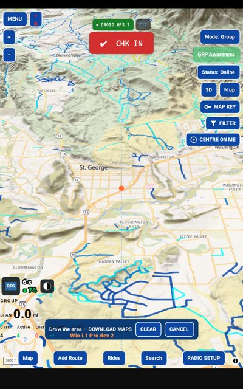

Prompt to draw area with your finger

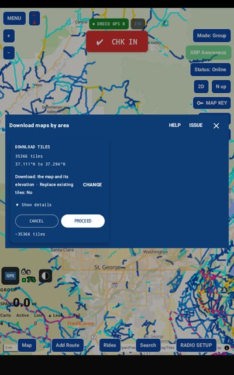

Tiles estimate, proceed with download

Step by step

1. Map › **Download maps by area**.
2. Draw a rectangle on the map with your finger round the area (**CLEAR** to draw again).
3. The summary shows how many tiles it will download. **CHANGE** alters the download settings for this download only; **Show details** lists the zoom levels.
4. **PROCEED** — the maps go into the download queue.

**Download settings**

Overview

**What it does.** Sets how every download behaves. Replace (on by default) downloads the maps again even where you already have them.

**How you use it.** Leave Replace on. Turn it off only to save data on a slow or metered connection.

**What it means to you.** With Replace on, downloading a track or area before you ride it guarantees you have the latest maps.

**When to use it.** Before a ride, to refresh the maps for that track or area; or on a metered connection.

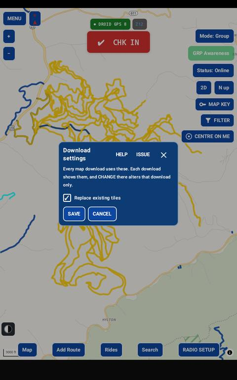

Replace existing tiles — on by default

Step by step

Map › **Download settings**, then **SAVE**.

**Replace — on by default.** On, every download fetches the maps again, even where you have them: the new map downloads fast, so this is the quickest way to be sure your maps are current. Turn it off to skip maps you already have — for example on a slow or metered connection. **Either way, maps you do not have are always downloaded** — Replace only decides whether the ones you have are fetched again (2.7e, 7 November 2026). Each download shows this setting, and its CHANGE alters that download only.

**Downloads — the queue**

What is it?

The download queue: what is downloading, how many tiles, how fast, and when it will be done.

How do I use it?

The first line of the Map menu shows it (No maps downloading, or the progress); a small box on the map shows it too. Tap **DETAILS ›** (or the box) for the queue:

- The top line: jobs active, tiles to go, the time left and when it will be done.
- **ALL / AREA / CORR / RFSH / DEL** show one kind of job (area downloads, corridors along tracks, refreshes, removals).
- **HOLD** pauses the queue (RELEASE starts it again); **X** on a job cancels it; **CANCEL ALL** cancels everything waiting; **CLEAR ALL** clears the completed list.

[figure not shown]

Queued downloads being processed

**The queue.** Top line: jobs active, tiles to go, the time left and when it will be done. ALL / AREA / CORR / RFSH / DEL show one kind of job. HOLD pauses; X cancels a job; CANCEL ALL cancels everything waiting; COMPLETED (folded) lists finished jobs; CLEAR ALL clears it.

What does it mean to me?

You always know when your maps will be ready — and downloads carry on while you use the map.

**Import files — GPX, KML, KMZ, GeoJSON (one import, 2.7e)**

Overview

**What it does.** A powerful tool: it brings trails, tracks, routes and waypoints into GroupTrack<sup>OG</sup> from a file — a local trail map you found on the internet, another app's export, or a file someone emailed you.

**How you use it.** Search the internet for local trail sources in a digital format (GPX, KML, KMZ or GeoJSON) and download the file to your tablet. Pick it here. A trail map: answer YES to "Are these files trails?" and give it a source name. Your own rides, routes and waypoints: answer NO. Tap IMPORT.

**What it means to you.** Your trails are unlimited: every park, club, county or forest trail map you find makes your maps and route planning better. The source name lets you take an import back out if it isn't useful.

**When to use it.** A park or club publishes its trail map; you move from onX or Gaia; a friend sends you a ride.

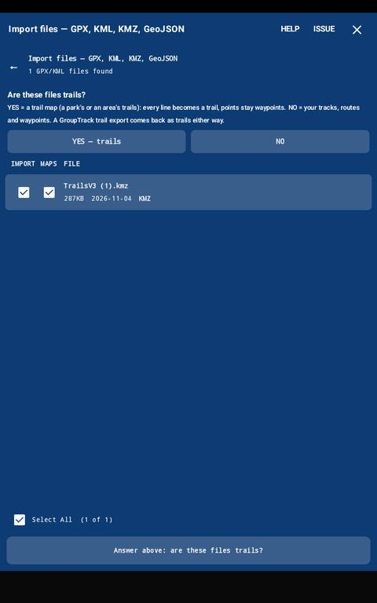

Before answering: IMPORT waits — "Answer above: are these files trails?"

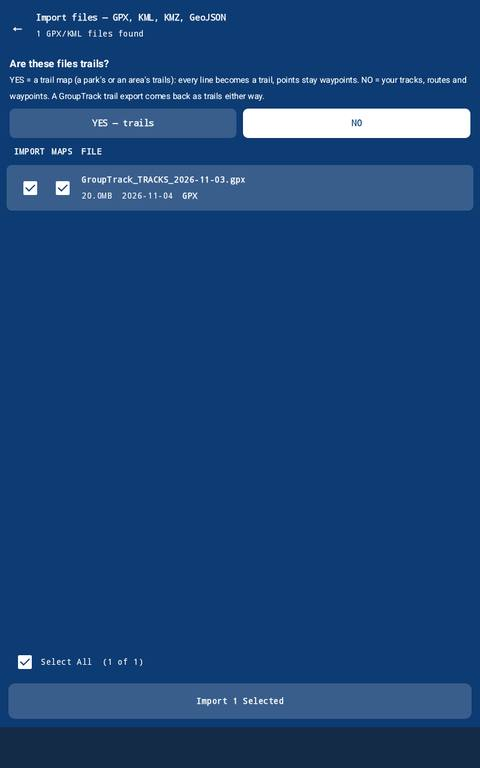

Opened from email: the file listed with NO already selected

[figure not shown]

Email GPX, then the file clicked

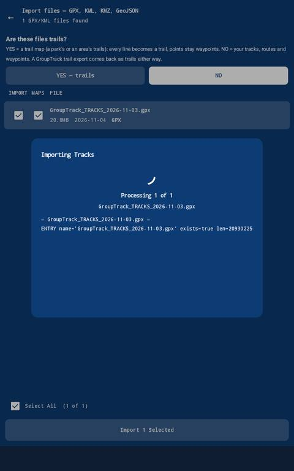

Import processing

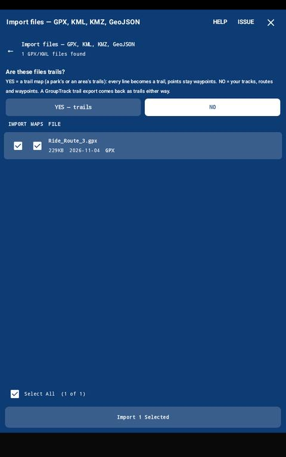

onX / Gaia GPX: route, track and waypoint imports

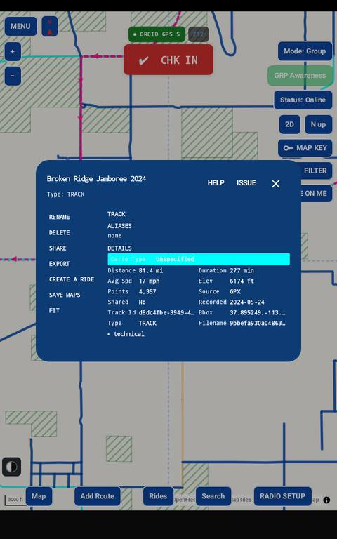

Discovering a trail, track or route source: its details panel

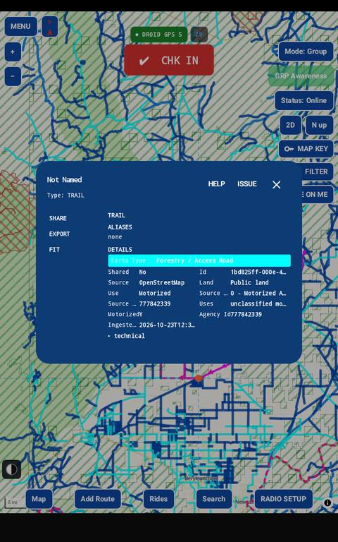

Trail source: where a trail came from, on its details

Step by step

1. **Find the file.** Search the internet for the trail map of a park, a riding club, a county or a forest, in GPX, KML, KMZ or GeoJSON, and download it to your tablet. Or use a file from onX, Gaia or a friend.
2. Map › IMPORT MAP FEATURES › **Import files — GPX, KML, KMZ, GeoJSON**. A notice explains Android's file picker; **CONTINUE**, then choose the file(s).
3. **You must answer before anything is imported.** Until you do, IMPORT reads "Answer above: are these files trails?" and does nothing. Both answers start faint; the one you tap fills solid — a white box with blue letters on the dark-blue panel (a blue box with white letters on the light panel). Then the button reads **Import N Selected as TRAILS** for YES, or **Import N Selected** for NO.
4. Answer **Are these files trails?** **YES — trails** for a trail map: every line becomes a trail, points stay waypoints, and a difficulty in the file is added to the trail's name. Give the batch a **Source name** (it starts as the file's name): it shows on every trail's details, and Delete imported trails by source removes the batch in one step. **NO** for your own rides, routes and waypoints: GPX goes in as the types it holds; KML, KMZ and GeoJSON lines come in as tracks.
5. Tick **IMPORT** for each file (and, for NO, **MAPS** to download the maps along each track). Tap **Import … Selected** (**as TRAILS** for YES).
6. A file that is not GPX — and every file answered YES — is converted first: the feed shows CONVERTED and the new file, also saved to Download (`…-Trails.gpx` or `…-Converted.gpx`). **Import Complete** shows what was new, a duplicate, skipped or failed.

**Opened from email:** tap a GPX or KML attachment and choose GroupTrack<sup>OG</sup>: the same screen opens with the file listed and **NO** already selected — tap YES first if it is a trail map. A ride invitation opens the same way.

**Why the question?** Inside a file a trail map and a recorded track are the same thing — a line. Only you can say which it is. A GroupTrack<sup>OG</sup> trail export carries GroupTrack<sup>OG</sup>'s trail mark and comes back as trails either way.

**Before the picker,** GroupTrack<sup>OG</sup> tells you that you are leaving it for Android's file picker, and how to come back: the back arrow on the bar at the bottom of the screen, or a swipe in from the right edge. Tap **CONTINUE**.

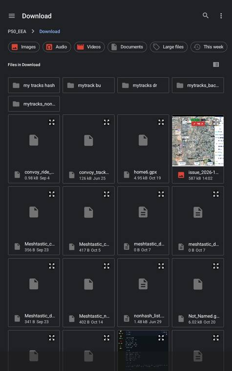

Android file picker in downloads to select file being processed

**Finding your GPX file in a busy Downloads folder.** The picker shows every file, so narrow it:

- **Search by name:** tap 🔍 at the top right and type **gpx**. Only files with that in their name are left. Tap the one you want.
- **Just downloaded it?** Tap **This week** in the row of buttons under the folder name: only files from the last seven days are left.
- **Names cut short?** Tap the list button at the right of **Files in Download**: one file per line, with its full name, size and date.
- **Looking for a GPX file?** A GPX file may show in the picker as a **bin** (binary) file — Android does not know the GPX type. That is normal: look for the name ending in **.gpx** and pick it.
- **Not in Downloads?** Tap ☰ at the top left and choose where it is — for example Google Drive.
- **Changed your mind?** The back arrow, or a swipe in from the right edge, takes you back to GroupTrack<sup>OG</sup> without a file.

To bring in several files at once, touch and hold the first, then tap the others, then **Select**.

**Back in GroupTrack<sup>OG</sup>,** each file you picked is listed.

- **IMPORT** ticked: the file is brought in. Untick a file to leave it out.
- **MAPS** ticked: the maps along it are downloaded too.
- Tap **Import Selected**.

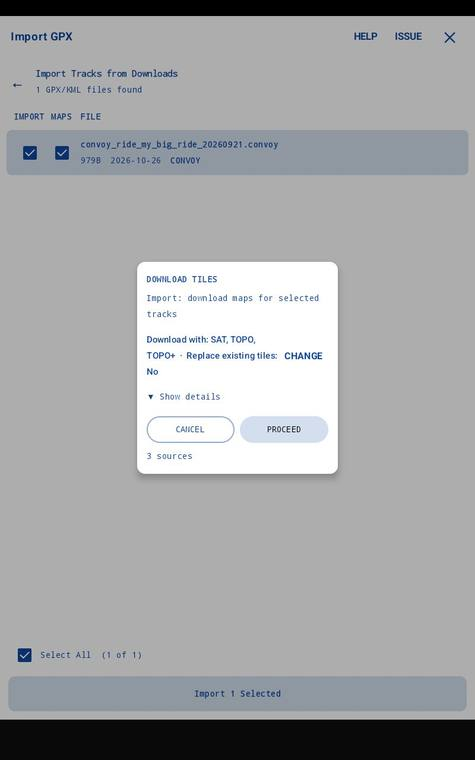

Confirmation of corridor maps

**If MAPS was ticked,** confirm the download: the map sources it will use (CHANGE them for this download only), then **PROCEED**. The maps join the download queue.

**DELETE FILES & CLOSE** removes the picked files from Downloads; **KEEP FILES & CLOSE** leaves them there.

One import brings in trails, tracks, routes and waypoints. For a trail map — every line a trail — answer **YES** to “Are these files trails?” and give it a source name; for your own tracks, routes and waypoints answer **NO**.

**Import trails by area**

Overview

**What it does.** The same as Import trails by state, for a box you draw — part of a state, or across state borders. Every state the box touches is downloaded and processed.

**How you use it.** Draw the box round where you ride, check the states and sources it lists, tap IMPORT. Run it again at least once a season to pick up new trails.

**What it means to you.** A complete set of trails for the area, across state lines, without loading whole states.